# Statistics for Data Science with `R`

- About this course
- Acknowledgements
- Basic Statistics
- Descriptive Statistics
- Distributions
- Inferential Statistics
- Linear Models
- Introduction
- t-test, ANOVA
- Regression
- Complex Linear Models
- Some Theory on LM
- Generalized Linear Models
- Introduction
- Binomial
- Poisson
- Gamma
- Some Theory on GLM
- Other GLM
- Introduction
- Multinomial Logistic
- Ordered Logit Model
- Negative Binomial Model
- Some Theory on other GLM
- Other Models
- Neural networks,GAM, ...
- Appendices
- Diagnostics
- AIC
- Sum of Squares
- Fixed Effects
- Nested ANOVA

# Multinomial Logit Examples

```r
require(MASS)
require(ggplot2)
require(nnet)
require(vcd)
require(qdata)
```

## Example: American National Election Study (from Faraway(2006): Extending the Linear Model with R)

### Data description

We will consider an example drawn from a subset of the 1996 American National Election Study (Rosenstone, Kinder, and Miller (1997)). Only age, education level and income group of the respondents will be considered for the example. The response variable will be party identification of the respondent, as: `Democrat`, `Independent` or `Republican`. Since the original data involved more than three dependent variable categories, we will collapsed these to three only, again for simplicity of the presentation.

### Data loading

Let us load the data

```r
data(nes96)
head(nes96)
```

```
## # A tibble: 6 x 10
##   popul TVnews selfLR ClinLR DoleLR     PID   age  educ   income    vote
##   <int>  <int>  <ord>  <ord>  <ord>   <ord> <int> <ord>    <ord>  <fctr>
## 1     0      7 extCon extLib    Con  strRep    36    HS $3Kminus    Dole
## 2   190      1 sliLib sliLib sliCon weakDem    20  Coll $3Kminus Clinton
## 3    31      7    Lib    Lib    Con weakDem    24 BAdeg $3Kminus Clinton
## 4    83      4 sliLib    Mod sliCon weakDem    28 BAdeg $3Kminus Clinton
## 5   640      7 sliCon    Con    Mod  strDem    68 BAdeg $3Kminus Clinton
## 6   110      3 sliLib    Mod    Con weakDem    21  Coll $3Kminus Clinton
```

```r
str(nes96)
```

```
## Classes 'tbl_df', 'tbl' and 'data.frame':    944 obs. of  10 variables:
##  $ popul : int  0 190 31 83 640 110 100 31 180 2800 ...
##  $ TVnews: int  7 1 7 4 7 3 7 1 7 0 ...
##  $ selfLR: Ord.factor w/ 7 levels "extLib"<"Lib"<..: 7 3 2 3 5 3 5 5 4 3 ...
##  $ ClinLR: Ord.factor w/ 7 levels "extLib"<"Lib"<..: 1 3 2 4 6 4 6 4 6 3 ...
##  $ DoleLR: Ord.factor w/ 7 levels "extLib"<"Lib"<..: 6 5 6 5 4 6 4 5 3 7 ...
##  $ PID   : Ord.factor w/ 7 levels "strDem"<"weakDem"<..: 7 2 2 2 1 2 2 5 4 1 ...
##  $ age   : int  36 20 24 28 68 21 77 21 31 39 ...
##  $ educ  : Ord.factor w/ 7 levels "MS"<"HSdrop"<..: 3 4 6 6 6 4 4 4 4 3 ...
##  $ income: Ord.factor w/ 24 levels "$3Kminus"<"$3K-$5K"<..: 1 1 1 1 1 1 1 1 1 1 ...
##  $ vote  : Factor w/ 2 levels "Clinton","Dole": 2 1 1 1 1 1 1 1 1 1 ...
```

```r
summary(nes96)
```

```
##      popul            TVnews         selfLR       ClinLR       DoleLR
##  Min.   :   0.0   Min.   :0.000   extLib: 16   extLib:109   extLib: 13
##  1st Qu.:   1.0   1st Qu.:1.000   Lib   :103   Lib   :317   Lib   : 31
##  Median :  22.0   Median :3.000   sliLib:147   sliLib:236   sliLib: 43
##  Mean   : 306.4   Mean   :3.728   Mod   :256   Mod   :160   Mod   : 87
##  3rd Qu.: 110.0   3rd Qu.:7.000   sliCon:170   sliCon: 67   sliCon:195
##  Max.   :7300.0   Max.   :7.000   Con   :218   Con   : 36   Con   :460
##                                   extCon: 34   extCon: 19   extCon:115
##       PID           age            educ           income         vote
##  strDem :200   Min.   :19.00   MS    : 13   $60K-$75K:103   Clinton:551
##  weakDem:180   1st Qu.:34.00   HSdrop: 52   $50K-$60K:100   Dole   :393
##  indDem :108   Median :44.00   HS    :248   $30K-$35K: 70
##  indind : 37   Mean   :47.04   Coll  :187   $25K-$30K: 68
##  indRep : 94   3rd Qu.:58.00   CCdeg : 90   $105Kplus: 68
##  weakRep:150   Max.   :91.00   BAdeg :227   $35K-$40K: 62
##  strRep :175                   MAdeg :127   (Other)  :473
```

### Descriptives

We create a new variable that will contain recoded `PID` data

```r
sPID <- nes96$PID
levels(sPID) <-  c("Democrat","Democrat","Independent","Independent",
                  "Independent","Republican","Republican")
summary(sPID)
```

```
##    Democrat Independent  Republican
##         380         239         325
```

```r
nes96$sPID <- sPID
```

Now we create a new numerical `nincome` variable containing the numerical transformation of original ordered-factor `income` variable, using midpoints of each range:

```r
inca <- c(1.5,4,6,8,9.5,10.5,11.5,12.5,13.5,14.5,16,18.5,21,23.5,
         27.5,32.5,37.5,42.5,47.5,55,67.5,82.5,97.5,115)
nincome <- inca[unclass(nes96$income)]
nes96$nincome <- nincome
summary(nes96$nincome)
```

```
##    Min. 1st Qu.  Median    Mean 3rd Qu.    Max.
##    1.50   23.50   37.50   46.58   67.50  115.00
```

Let us start with a graphical look at the relationship between the predictors and the response.

```r
table(nes96$educ)
```

```
##
##     MS HSdrop     HS   Coll  CCdeg  BAdeg  MAdeg
##     13     52    248    187     90    227    127
```

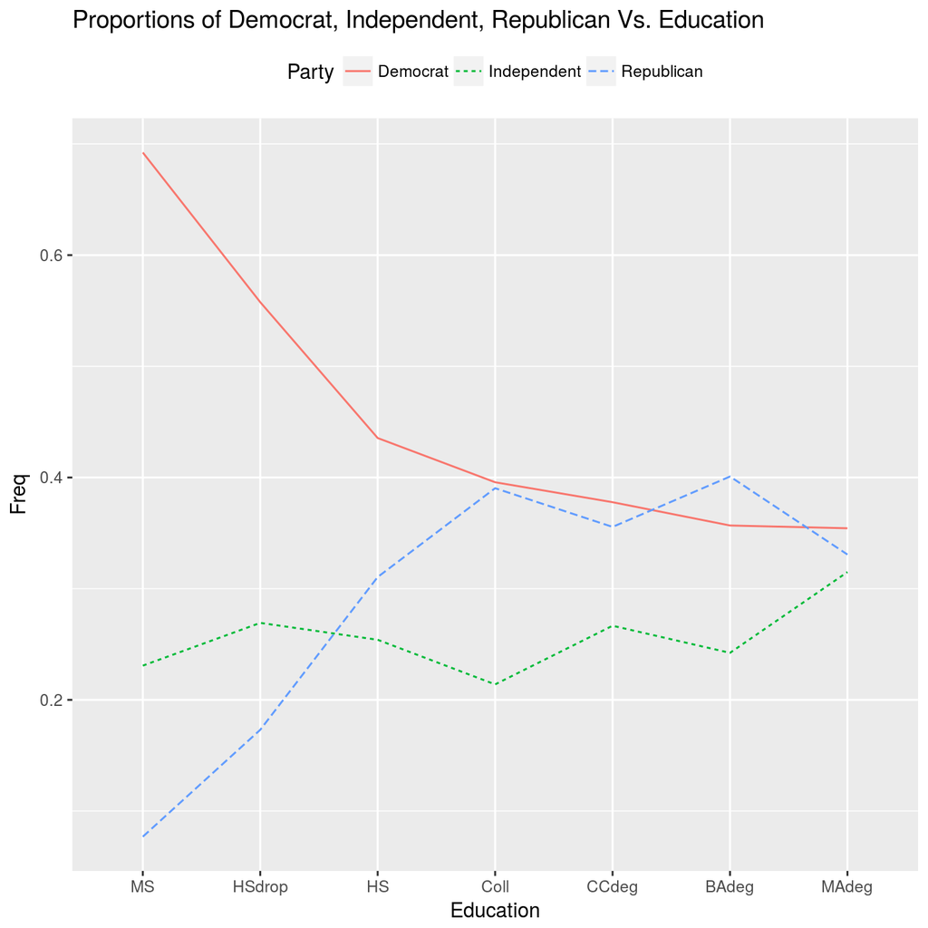

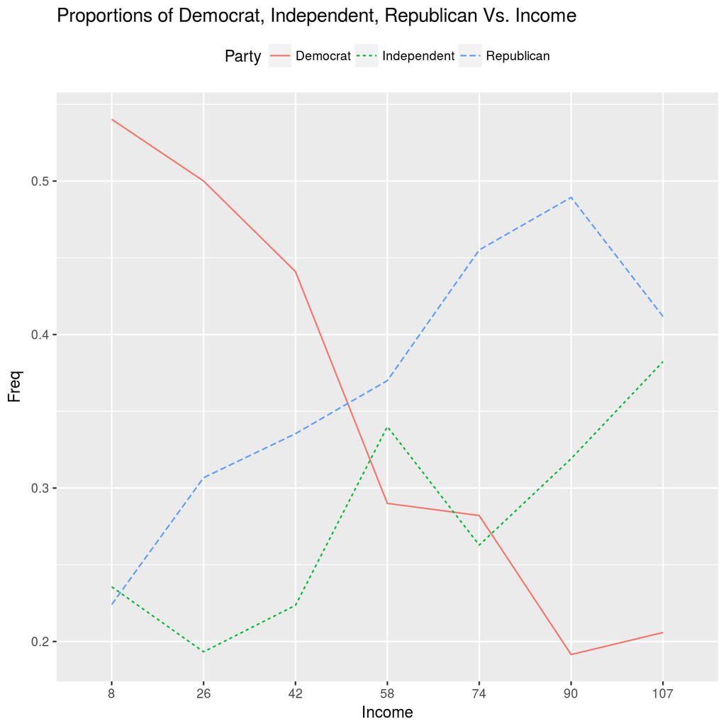

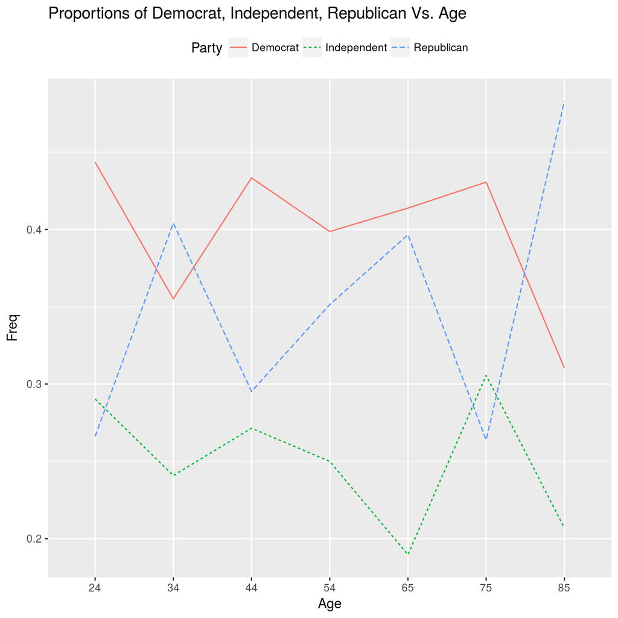

```r
ptb <- data.frame(prop.table(table(nes96$educ,nes96$sPID),1))
names(ptb) <- c("Education", "Party", "Freq")
ggp <- ggplot(data = ptb, mapping = aes(x=Education, y = Freq)) +
  geom_line(mapping = aes(colour= Party, linetype=Party, group=Party) ) +
  ggtitle("Proportions of Democrat, Independent, Republican Vs. Education") +
  theme(legend.position="top")
print(ggp)

cutinc <- cut(nes96$nincome,7)
il <- c(8,26,42,58,74,90,107)
ptb <- data.frame(as.factor(il), prop.table(table(cutinc,nes96$sPID),1))
names(ptb) <- c("Income", "cutinc","Party", "Freq")
ggp <- ggplot(data = ptb, mapping = aes(x=Income, y = Freq)) +
  geom_line(mapping = aes(colour= Party, linetype=Party, group=Party) ) +
  ggtitle("Proportions of Democrat, Independent, Republican Vs. Income") +
  theme(legend.position="top")
print(ggp)

cutage <- cut(nes96$age,7)
al <- c(24,34,44,54,65,75,85)
ptb <- data.frame(as.factor(al), prop.table(table(cutage,nes96$sPID),1))
names(ptb) <- c("Age", "cutage","Party", "Freq")
ggp <- ggplot(data = ptb, mapping = aes(x=Age, y = Freq)) +
  geom_line(mapping = aes(colour= Party, linetype=Party, group=Party) ) +
  ggtitle("Proportions of Democrat, Independent, Republican Vs. Age") +
  theme(legend.position="top")
print(ggp)
```

### Inference and models

We might ask whether the trends we see in the observed proportions are statistically significant. We need to model the data to answer this question. We fit a multinomial logit model. We will use the `multinom()` function, which is part of the `nnet` package:

```r
(mmod0 <- multinom(sPID ~ age + educ + nincome, data=nes96))
```

```
## Call:
## multinom(formula = sPID ~ age + educ + nincome, data = nes96)
##
## Coefficients:
##             (Intercept)          age     educ.L     educ.Q    educ.C
## Independent   -1.197260 0.0001534525 0.06351451 -0.1217038 0.1119542
## Republican    -1.642656 0.0081943691 1.19413345 -1.2292869 0.1544575
##                  educ^4     educ^5      educ^6    nincome
## Independent -0.07657336  0.1360851  0.15427826 0.01623911
## Republican  -0.02827297 -0.1221176 -0.03741389 0.01724679
##
## Residual Deviance: 1968.333
## AIC: 2004.333
```

```r
summary(mmod0)
```

```
## Call:
## multinom(formula = sPID ~ age + educ + nincome, data = nes96)
##
## Coefficients:
##             (Intercept)          age     educ.L     educ.Q    educ.C
## Independent   -1.197260 0.0001534525 0.06351451 -0.1217038 0.1119542
## Republican    -1.642656 0.0081943691 1.19413345 -1.2292869 0.1544575
##                  educ^4     educ^5      educ^6    nincome
## Independent -0.07657336  0.1360851  0.15427826 0.01623911
## Republican  -0.02827297 -0.1221176 -0.03741389 0.01724679
##
## Std. Errors:
##             (Intercept)         age    educ.L    educ.Q    educ.C
## Independent   0.3265951 0.005374592 0.4571884 0.4142859 0.3498491
## Republican    0.3312877 0.004902668 0.6502670 0.6041924 0.4866432
##                educ^4    educ^5    educ^6     nincome
## Independent 0.2883031 0.2494706 0.2171578 0.003108585
## Republican  0.3605620 0.2696036 0.2031859 0.002881745
##
## Residual Deviance: 1968.333
## AIC: 2004.333
```

Roughly speaking, the multinomial model is a “combination” of $k$-1 Binomial models (where, in this case, $k$=3, is the number of levels of dependent variable) which compare the probability of being `Independent` or `Republican` with respect to the probability being `Democrat`, given the values of independent variables.

As for “standard” LM-GLM models, we can use stepwise methods to analyse which variables include to/exclude from model:

```r
mmod <- step(mmod0)
```

```
## Start:  AIC=2004.33
## sPID ~ age + educ + nincome
##
## trying - age
## trying - educ
## trying - nincome
##           Df      AIC
## - educ     6 1996.539
## - age     16 2003.625
## <none>    18 2004.333
## - nincome 16 2045.911
##
## Step:  AIC=1996.54
## sPID ~ age + nincome
##
## trying - age
## trying - nincome
##           Df      AIC
## - age      4 1993.424
## <none>     6 1996.539
## - nincome  4 2048.850
##
## Step:  AIC=1993.42
## sPID ~ nincome
##
## trying - nincome
##           Df      AIC
## <none>     4 1993.424
## - nincome  2 2045.272
```

`mmod` is the resulting selected model:

```r
summary(mmod)
```

```
## Call:
## multinom(formula = sPID ~ nincome, data = nes96)
##
## Coefficients:
##             (Intercept)    nincome
## Independent  -1.1749331 0.01608683
## Republican   -0.9503591 0.01766457
##
## Std. Errors:
##             (Intercept)     nincome
## Independent   0.1536103 0.002849738
## Republican    0.1416859 0.002652532
##
## Residual Deviance: 1985.424
## AIC: 1993.424
```

The above results show the coefficients estimates for the $k$-1 models (the first matrix), with their standard errors (the second matrix).

We may also use the standard likelihood methods to derive a test to compare nested models. For example, we can fit a model without education and then compare the deviances:

```r
(mmod1 <- multinom(sPID ~ age + nincome, data=nes96))
```

```
## Call:
## multinom(formula = sPID ~ age + nincome, data = nes96)
##
## Coefficients:
##             (Intercept)          age   nincome
## Independent   -1.187181 0.0002260719 0.0161244
## Republican    -1.154787 0.0041328499 0.0178682
##
## Residual Deviance: 1984.539
## AIC: 1996.539
```

```r
summary(mmod1)
```

```
## Call:
## multinom(formula = sPID ~ age + nincome, data = nes96)
##
## Coefficients:
##             (Intercept)          age   nincome
## Independent   -1.187181 0.0002260719 0.0161244
## Republican    -1.154787 0.0041328499 0.0178682
##
## Std. Errors:
##             (Intercept)         age     nincome
## Independent   0.2941042 0.005143979 0.002861903
## Republican    0.2736512 0.004700426 0.002666931
##
## Residual Deviance: 1984.539
## AIC: 1996.539
```

This is the LRT test, with relative p-value:

```r
diff <- deviance(mmod1) - deviance(mmod0)
diff
```

```
## [1] 16.20642
```

```r
pchisq(diff,mmod0$edf-mmod1$edf,lower=F)
```

```
## [1] 0.1819634
```

```r
anova(mmod0, mmod1, test="Chisq")
```

```
## Likelihood ratio tests of Multinomial Models
##
## Response: sPID
##                  Model Resid. df Resid. Dev   Test    Df LR stat.
## 1        age + nincome      1882   1984.539
## 2 age + educ + nincome      1870   1968.333 1 vs 2    12 16.20642
##     Pr(Chi)
## 1
## 2 0.1819634
```

And, not surprisingly, if we want to apply a Type II test to choose which explicative variable to remove (if any), we may use `dropterm()`:

```r
dropterm(mmod0, test="Chisq")
```

```
## Single term deletions
##
## Model:
## sPID ~ age + educ + nincome
##         Df    AIC    LRT   Pr(Chi)
## <none>     2004.3
## age      2 2003.6  3.293    0.1927
## educ    12 1996.5 16.206    0.1820
## nincome  2 2045.9 45.578 1.267e-10 ***
## ---
## Signif. codes:  0 '***' 0.001 '**' 0.01 '*' 0.05 '.' 0.1 ' ' 1
```

which suggests first to drop `age`. Now we can also check if other variables can be removed from model, again using `dropterm()`:

```r
mmod2 <- multinom(sPID ~ educ + nincome, data=nes96)
dropterm(mmod2, test="Chisq")
```

```
## Single term deletions
##
## Model:
## sPID ~ educ + nincome
##         Df    AIC    LRT   Pr(Chi)
## <none>     2003.6
## educ    12 1993.4 13.799    0.3137
## nincome  2 2044.8 45.171 1.553e-10 ***
## ---
## Signif. codes:  0 '***' 0.001 '**' 0.01 '*' 0.05 '.' 0.1 ' ' 1
```

and then to drop `educ`:

```r
mmod3 <- multinom(sPID ~ nincome, data=nes96)
dropterm(mmod3, test="Chisq")
```

```
## Single term deletions
##
## Model:
## sPID ~ nincome
##         Df    AIC    LRT   Pr(Chi)
## <none>     1993.4
## nincome  2 2045.3 55.848 7.461e-13 ***
## ---
## Signif. codes:  0 '***' 0.001 '**' 0.01 '*' 0.05 '.' 0.1 ' ' 1
```

`mmod3` is the same model as `mmod`.

The non significancy of `educ` is in some manner surprising, but this may depend from the fact that the big differences in proportions between `Democrat` and `Independent` or `Republican` appear only at low educaction levels, where there are small samples; also, low education levels are probably related to low `nincome` values, and then `educ` could not add useful information, once considered `nicome`.

Anyway, for tests on predictors it is better to consider likelihood ratio tests rather than Wald tests, since for one predictor we have $k$-1 Wald tests.

We may also examine the coefficients to gain an understanding of the relationship between the predictor and the response:

```r
summary(mmod)
```

```
## Call:
## multinom(formula = sPID ~ nincome, data = nes96)
##
## Coefficients:
##             (Intercept)    nincome
## Independent  -1.1749331 0.01608683
## Republican   -0.9503591 0.01766457
##
## Std. Errors:
##             (Intercept)     nincome
## Independent   0.1536103 0.002849738
## Republican    0.1416859 0.002652532
##
## Residual Deviance: 1985.424
## AIC: 1993.424
```

Effective degrees of freedom is equal to the number of parameters

```r
mmod$edf
```

```
## [1] 4
```

To obtain coefficients:

```r
coef(mmod)
```

```
##             (Intercept)    nincome
## Independent  -1.1749331 0.01608683
## Republican   -0.9503591 0.01766457
```

the deviance:

```r
mmod$deviance
```

```
## [1] 1985.424
```

ad the AIC:

```r
mmod$AIC
```

```
## [1] 1993.424
```

Both residuals and fitted values are referred to all $k$ classes of the response variable

```r
head(mmod$residuals); head(mmod$fitted.values)
```

```
##     Democrat Independent Republican
## 1 -0.5836466  -0.1846557  0.7683023
## 2  0.4163534  -0.1846557 -0.2316977
## 3  0.4163534  -0.1846557 -0.2316977
## 4  0.4163534  -0.1846557 -0.2316977
## 5  0.4163534  -0.1846557 -0.2316977
## 6  0.4163534  -0.1846557 -0.2316977
```

```
##    Democrat Independent Republican
## 1 0.5836466   0.1846557  0.2316977
## 2 0.5836466   0.1846557  0.2316977
## 3 0.5836466   0.1846557  0.2316977
## 4 0.5836466   0.1846557  0.2316977
## 5 0.5836466   0.1846557  0.2316977
## 6 0.5836466   0.1846557  0.2316977
```

```r
summary(mmod)
```

```
## Call:
## multinom(formula = sPID ~ nincome, data = nes96)
##
## Coefficients:
##             (Intercept)    nincome
## Independent  -1.1749331 0.01608683
## Republican   -0.9503591 0.01766457
##
## Std. Errors:
##             (Intercept)     nincome
## Independent   0.1536103 0.002849738
## Republican    0.1416859 0.002652532
##
## Residual Deviance: 1985.424
## AIC: 1993.424
```

Now, with the simpler model, we could try to produce some predictions (remember that `il` contains the midpoint of income):

```r
predict(mmod, data.frame(nincome=il), type="probs")
```

```
##    Democrat Independent Republican
## 1 0.5566253   0.1955183  0.2478565
## 2 0.4804946   0.2254595  0.2940459
## 3 0.4134268   0.2509351  0.3356381
## 4 0.3493884   0.2743178  0.3762939
## 5 0.2903271   0.2948600  0.4148129
## 6 0.2375755   0.3121136  0.4503109
## 7 0.1891684   0.3266848  0.4841468
```

The calculations performed to obtain the predictions actually are:

```r
(predInd <- exp(-1.1749331+0.01608683*il) /
   (1+exp(-1.1749331+0.01608683*il)+exp(-0.9503591+0.01766457*il)))
```

```
## [1] 0.1955183 0.2254595 0.2509351 0.2743178 0.2948600 0.3121136 0.3266848
```

for `Indepentent`,

```r
(predRep <- exp(-0.9503591+0.01766457*il) /
   (1+exp(-1.1749331+0.01608683*il)+exp(-0.9503591+0.01766457*il)))
```

```
## [1] 0.2478564 0.2940459 0.3356381 0.3762938 0.4148128 0.4503108 0.4841467
```

for `Republican`, and

```r
(predDem <- 1-predInd-predRep)
```

```
## [1] 0.5566253 0.4804946 0.4134268 0.3493884 0.2903271 0.2375756 0.1891685
```

for `Democrat`.

The default form of predict (`type="class"`) just gives the most probable category:

```r
predict(mmod,data.frame(nincome=il))
```

```
## [1] Democrat   Democrat   Democrat   Republican Republican Republican
## [7] Republican
## Levels: Democrat Independent Republican
```

```r
summary(mmod)
```

```
## Call:
## multinom(formula = sPID ~ nincome, data = nes96)
##
## Coefficients:
##             (Intercept)    nincome
## Independent  -1.1749331 0.01608683
## Republican   -0.9503591 0.01766457
##
## Std. Errors:
##             (Intercept)     nincome
## Independent   0.1536103 0.002849738
## Republican    0.1416859 0.002652532
##
## Residual Deviance: 1985.424
## AIC: 1993.424
```

The intercept terms model the probabilities of the party identification for an income of zero. We can see the relationship from this calculation:

```r
cc <- c(0,-1.1749331,-0.9503591)
exp(cc)/sum(exp(cc))
```

```
## [1] 0.5898168 0.1821588 0.2280244
```

```r
sum(exp(cc)/sum(exp(cc)))
```

```
## [1] 1
```

The exp() of slope terms represent the odds-ratio (~ Relative Risk ratio) of moving from the baseline category of Democrat to Independent or Republican, respectively, for a unit change of $1000 in income. We can see more explicitly what this means by predicting probabilities for incomes $1000 apart and then computing the odds:

```r
(pp <- predict(mmod,data.frame(nincome=c(0,1)),type="probs"))
```

```
##    Democrat Independent Republican
## 1 0.5898168   0.1821588  0.2280244
## 2 0.5857064   0.1838228  0.2304708
```

```r
pp[1,1]*pp[2,2]/(pp[1,2]*pp[2,1])
```

```
## [1] 1.016217
```

```r
pp[1,1]*pp[2,3]/(pp[1,3]*pp[2,1])
```

```
## [1] 1.017822
```

Is the same of:

```r
exp(coefficients(mmod)[,2])
```

```
## Independent  Republican
##    1.016217    1.017822
```

Prediction capability

```r
table(predict(mmod), sPID)
```

```
##              sPID
##               Democrat Independent Republican
##   Democrat         284         123        166
##   Independent        0           0          0
##   Republican        96         116        159
```

This may appear a bit strange: no Indipendent is predicted? Why?

Analysis of residuals (they have to stay in two different portions): no `plot` method is available for objects from `multinom` models. We have to plot separately the residuals for each dependent variable class.  
For example:

`Independent`

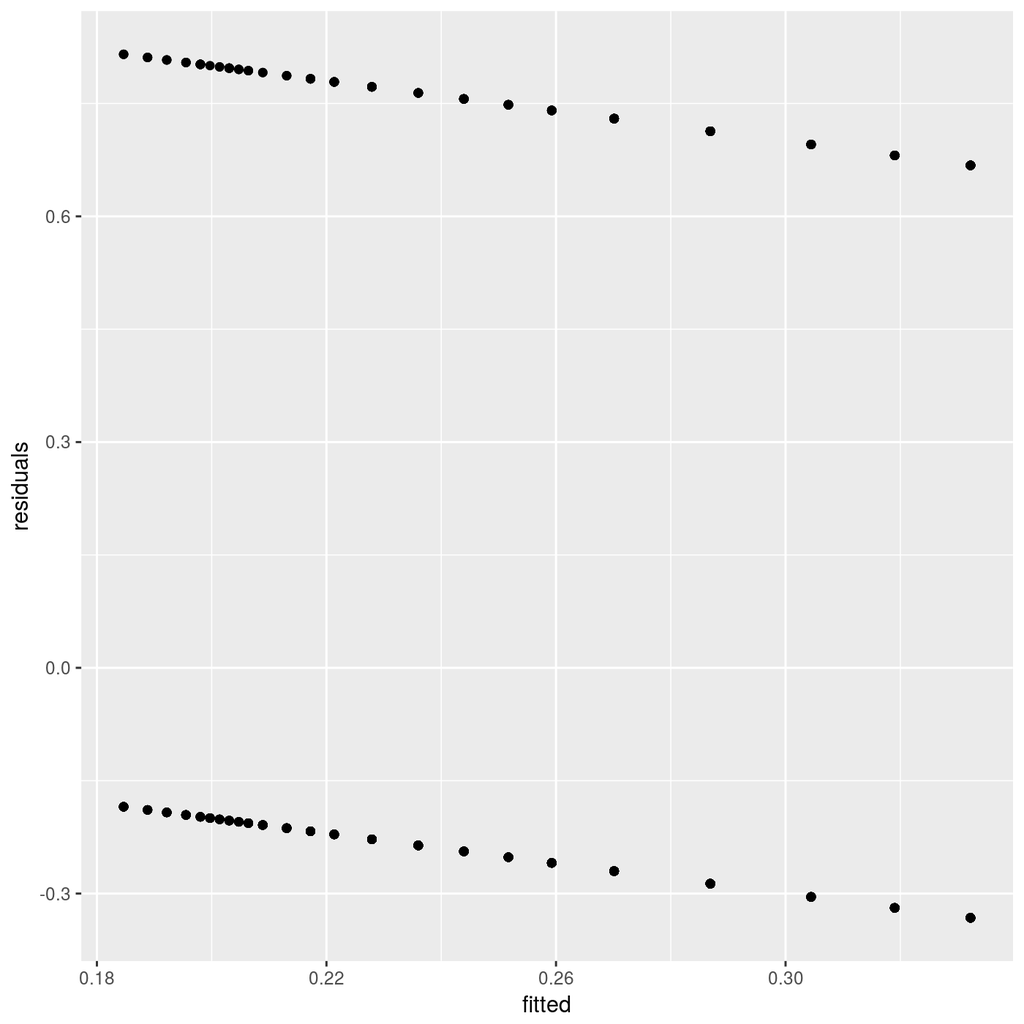

```r
ds <- data.frame(residuals = mmod$residuals[,2], fitted = mmod$fitted.values[,2])
ggp <- ggplot(data = ds, mapping = aes(x=fitted, y=residuals)) +
  geom_point()
print(ggp)
```

`Republican`

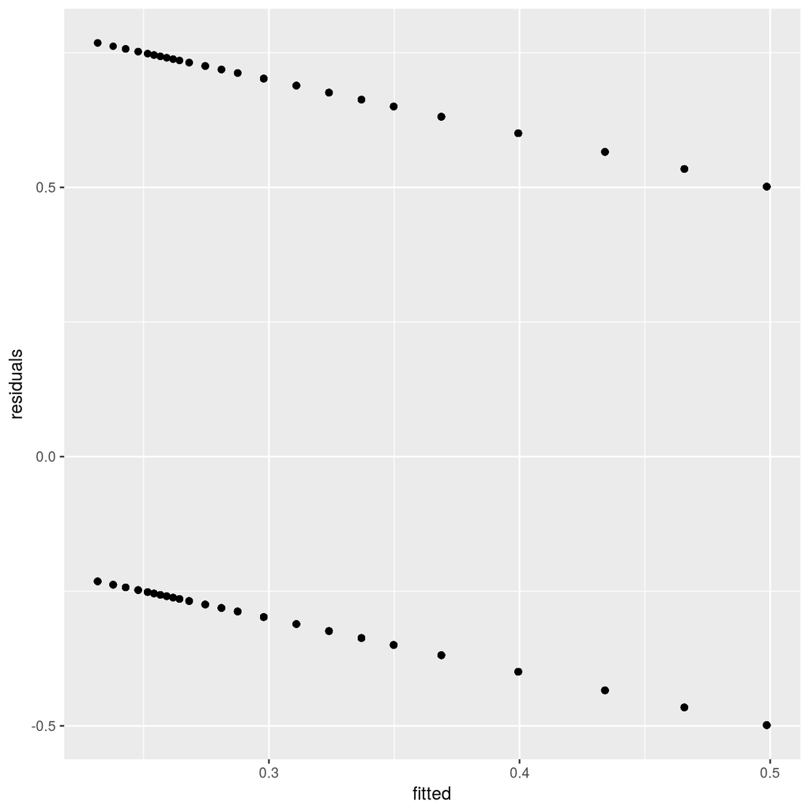

```r
ds <- data.frame(residuals = mmod$residuals[,3], fitted = mmod$fitted.values[,3])
ggp <- ggplot(data = ds, mapping = aes(x=fitted, y=residuals)) +
  geom_point()
print(ggp)
```

`Democrat`

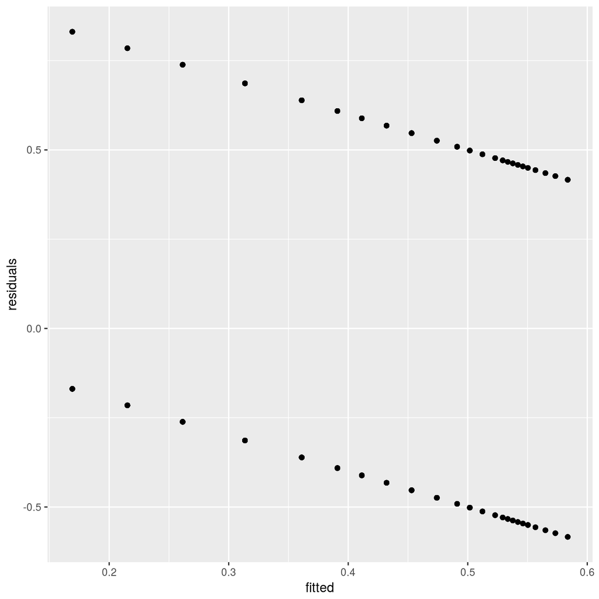

```r
ds <- data.frame(residuals = mmod$residuals[,1], fitted = mmod$fitted.values[,1])
ggp <- ggplot(data = ds, mapping = aes(x=fitted, y=residuals)) +
  geom_point()
print(ggp)
```

## Example: Housholders in Copenhagen

### Data description

1681 householders from a study of satisfaction with housing conditions in Copenhagen who were surveyed on:

- the type (`Type`) of rental accommodation they occupied
- the degree of contact (`Cont`) they had with other residents
- their feeling of influence (`Infl`) on apartment management
- their level of satisfaction (`Sat`) with their housing conditions

We want to check if the satisfation level may be related to other (independent) variables.

### Data loading

```r
data(housing)
head(housing)
```

```
## # A tibble: 6 x 5
##      Sat   Infl   Type   Cont  Freq
##    <ord> <fctr> <fctr> <fctr> <int>
## 1    Low    Low  Tower    Low    21
## 2 Medium    Low  Tower    Low    21
## 3   High    Low  Tower    Low    28
## 4    Low Medium  Tower    Low    34
## 5 Medium Medium  Tower    Low    22
## 6   High Medium  Tower    Low    36
```

```r
str(housing)
```

```
## Classes 'tbl_df', 'tbl' and 'data.frame':    72 obs. of  5 variables:
##  $ Sat : Ord.factor w/ 3 levels "Low"<"Medium"<..: 1 2 3 1 2 3 1 2 3 1 ...
##  $ Infl: Factor w/ 3 levels "Low","Medium",..: 1 1 1 2 2 2 3 3 3 1 ...
##  $ Type: Factor w/ 4 levels "Tower","Apartment",..: 1 1 1 1 1 1 1 1 1 2 ...
##  $ Cont: Factor w/ 2 levels "Low","High": 1 1 1 1 1 1 1 1 1 1 ...
##  $ Freq: int  21 21 28 34 22 36 10 11 36 61 ...
```

```r
summary(housing)
```

```
##      Sat         Infl           Type      Cont         Freq
##  Low   :24   Low   :24   Tower    :18   Low :36   Min.   : 3.00
##  Medium:24   Medium:24   Apartment:18   High:36   1st Qu.:10.00
##  High  :24   High  :24   Atrium   :18             Median :19.50
##                          Terrace  :18             Mean   :23.35
##                                                   3rd Qu.:31.75
##                                                   Max.   :86.00
```

### Descriptives

A four way frequency table may help in reading the relations

```r
ftable(xtabs(Freq ~ Infl+Type+Cont+Sat, data=housing))
```

```
##                       Sat Low Medium High
## Infl   Type      Cont
## Low    Tower     Low       21     21   28
##                  High      14     19   37
##        Apartment Low       61     23   17
##                  High      78     46   43
##        Atrium    Low       13      9   10
##                  High      20     23   20
##        Terrace   Low       18      6    7
##                  High      57     23   13
## Medium Tower     Low       34     22   36
##                  High      17     23   40
##        Apartment Low       43     35   40
##                  High      48     45   86
##        Atrium    Low        8      8   12
##                  High      10     22   24
##        Terrace   Low       15     13   13
##                  High      31     21   13
## High   Tower     Low       10     11   36
##                  High       3      5   23
##        Apartment Low       26     18   54
##                  High      15     25   62
##        Atrium    Low        6      7    9
##                  High       7     10   21
##        Terrace   Low        7      5   11
##                  High       5      6   13
```

```r
prop.table(ftable(xtabs(Freq ~ Infl+Type+Cont+Sat, data=housing)),margin = 1)
```

```
##                       Sat        Low     Medium       High
## Infl   Type      Cont
## Low    Tower     Low      0.30000000 0.30000000 0.40000000
##                  High     0.20000000 0.27142857 0.52857143
##        Apartment Low      0.60396040 0.22772277 0.16831683
##                  High     0.46706587 0.27544910 0.25748503
##        Atrium    Low      0.40625000 0.28125000 0.31250000
##                  High     0.31746032 0.36507937 0.31746032
##        Terrace   Low      0.58064516 0.19354839 0.22580645
##                  High     0.61290323 0.24731183 0.13978495
## Medium Tower     Low      0.36956522 0.23913043 0.39130435
##                  High     0.21250000 0.28750000 0.50000000
##        Apartment Low      0.36440678 0.29661017 0.33898305
##                  High     0.26815642 0.25139665 0.48044693
##        Atrium    Low      0.28571429 0.28571429 0.42857143
##                  High     0.17857143 0.39285714 0.42857143
##        Terrace   Low      0.36585366 0.31707317 0.31707317
##                  High     0.47692308 0.32307692 0.20000000
## High   Tower     Low      0.17543860 0.19298246 0.63157895
##                  High     0.09677419 0.16129032 0.74193548
##        Apartment Low      0.26530612 0.18367347 0.55102041
##                  High     0.14705882 0.24509804 0.60784314
##        Atrium    Low      0.27272727 0.31818182 0.40909091
##                  High     0.18421053 0.26315789 0.55263158
##        Terrace   Low      0.30434783 0.21739130 0.47826087
##                  High     0.20833333 0.25000000 0.54166667
```

A mosaic plot may improve the readability:

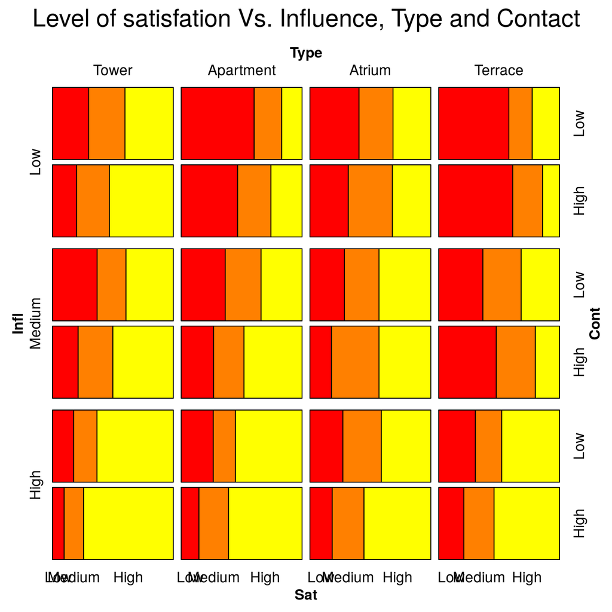

```r
strt <- structable(prop.table(ftable(xtabs(Freq ~ Infl+Type+Cont+Sat, data=housing)),margin = 1),
                data=housing)
mosaic(strt,shade=TRUE,main = "Level of satisfation Vs. Influence, Type and Contact",
       highlighting="Sat",highlighting_fill=heat.colors(3))
```

It seems that an high influence, Tower type of accomodation, and high level of contact gives more high satisfation.

### Inference and models

Let us start from the full model and then to remove non significant effects to confirm these readings:

```r
house_mult0 <- multinom(Sat ~ Infl*Type*Cont, weights=Freq, data=housing)
dropterm(house_mult0, test="Chisq")
```

```
## Single term deletions
##
## Model:
## Sat ~ Infl * Type * Cont
##                Df    AIC    LRT Pr(Chi)
## <none>            3527.4
## Infl:Type:Cont 12 3509.4 5.9443  0.9189
```

```r
house_mult1 <- update(house_mult0, . ~ . - Infl:Type:Cont, data=housing)
dropterm(house_mult1, test="Chisq")
```

```
## Single term deletions
##
## Model:
## Sat ~ Infl + Type + Cont + Infl:Type + Infl:Cont + Type:Cont
##           Df    AIC     LRT Pr(Chi)
## <none>       3509.4
## Infl:Type 12 3506.4 21.0580 0.04954 *
## Infl:Cont  4 3502.3  0.8840 0.92684
## Type:Cont  6 3506.7  9.2897 0.15793
## ---
## Signif. codes:  0 '***' 0.001 '**' 0.01 '*' 0.05 '.' 0.1 ' ' 1
```

```r
house_mult2 <- update(house_mult1, . ~ . - Infl:Cont, data=housing)
dropterm(house_mult2, test="Chisq")
```

```
## Single term deletions
##
## Model:
## Sat ~ Infl + Type + Cont + Infl:Type + Type:Cont
##           Df    AIC     LRT Pr(Chi)
## <none>       3502.3
## Infl:Type 12 3499.7 21.4275 0.04446 *
## Type:Cont  6 3499.5  9.2788 0.15850
## ---
## Signif. codes:  0 '***' 0.001 '**' 0.01 '*' 0.05 '.' 0.1 ' ' 1
```

```r
house_mult <- update(house_mult2, . ~ . - Type:Cont, data=housing)
dropterm(house_mult, test="Chisq")
```

```
## Single term deletions
##
## Model:
## Sat ~ Infl + Type + Cont + Infl:Type
##           Df    AIC    LRT   Pr(Chi)
## <none>       3499.5
## Cont       2 3512.3 16.764 0.0002289 ***
## Infl:Type 12 3498.1 22.555 0.0317500 *
## ---
## Signif. codes:  0 '***' 0.001 '**' 0.01 '*' 0.05 '.' 0.1 ' ' 1
```

The `Infl:Type` interaction term seems significant, but, since its exclusion form model reduces the AIC value, for sake of simplicity we remove the term and use a main effects only model.

```r
house_mult <- multinom(Sat ~ Infl+Type+Cont, weights=Freq, data=housing)
summary(house_mult)
```

```
## Call:
## multinom(formula = Sat ~ Infl + Type + Cont, data = housing,
##     weights = Freq)
##
## Coefficients:
##        (Intercept) InflMedium  InflHigh TypeApartment TypeAtrium
## Medium  -0.4192316  0.4464003 0.6649367    -0.4356851  0.1313663
## High    -0.1387453  0.7348626 1.6126294    -0.7356261 -0.4079808
##        TypeTerrace  ContHigh
## Medium  -0.6665728 0.3608513
## High    -1.4123333 0.4818236
##
## Std. Errors:
##        (Intercept) InflMedium  InflHigh TypeApartment TypeAtrium
## Medium   0.1729344  0.1415572 0.1863374     0.1725327  0.2231065
## High     0.1592295  0.1369380 0.1671316     0.1552714  0.2114965
##        TypeTerrace  ContHigh
## Medium   0.2062532 0.1323975
## High     0.2001496 0.1241371
##
## Residual Deviance: 3470.084
## AIC: 3498.084
```

```r
anova(house_mult0, house_mult)
```

```
## Likelihood ratio tests of Multinomial Models
##
## Response: Sat
##                Model Resid. df Resid. Dev   Test    Df LR stat.   Pr(Chi)
## 1 Infl + Type + Cont       130   3470.084
## 2 Infl * Type * Cont        96   3431.422 1 vs 2    34 38.66219 0.2671367
```

Removing the interaction terms seems not reduce the explicative power of model.

```r
coef(house_mult)
```

```
##        (Intercept) InflMedium  InflHigh TypeApartment TypeAtrium
## Medium  -0.4192316  0.4464003 0.6649367    -0.4356851  0.1313663
## High    -0.1387453  0.7348626 1.6126294    -0.7356261 -0.4079808
##        TypeTerrace  ContHigh
## Medium  -0.6665728 0.3608513
## High    -1.4123333 0.4818236
```

At first sight, it seems that the initial thoughts about relations between independent variables and Satisfation are confirmed.

### Multinomial models and Poisson models

Multinomial logit models can be analyzed also via standard GLM, using a Poisson model. This approach is also called “surrogate Poisson model”.

Suppose we are interested only on influence of main effects of `Infl`, `Type` and `Cont` on `Sat`. Since we are only interested in satisfaction, we need to include terms in the model to account for all the history variables, so the minimal model is `Infl*Type*Cont`.  
To check effect of explicative variables main effects on `Sat`, we must also include the `Sat*(Infl+Type+Cont)` interaction in model:

```r
llmod <- glm(Freq ~ Infl*Type*Cont + Sat*(Infl+Type+Cont), data=housing, family=poisson)
summary(llmod)
```

```
##
## Call:
## glm(formula = Freq ~ Infl * Type * Cont + Sat * (Infl + Type +
##     Cont), family = poisson, data = housing)
##
## Deviance Residuals:
##     Min       1Q   Median       3Q      Max
## -1.6022  -0.5282  -0.0641   0.5757   1.9322
##
## Coefficients:
##                                    Estimate Std. Error z value Pr(>|z|)
## (Intercept)                        3.135074   0.120112  26.101  < 2e-16
## InflMedium                         0.248327   0.159979   1.552 0.120602
## InflHigh                          -0.412645   0.184947  -2.231 0.025671
## TypeApartment                      0.292524   0.157477   1.858 0.063231
## TypeAtrium                        -0.792847   0.214413  -3.698 0.000218
## TypeTerrace                       -1.018074   0.221263  -4.601 4.20e-06
## ContHigh                          -0.001407   0.169711  -0.008 0.993385
## Sat.L                             -0.098106   0.112592  -0.871 0.383570
## Sat.Q                              0.285657   0.122283   2.336 0.019489
## InflMedium:TypeApartment          -0.017882   0.210496  -0.085 0.932302
## InflHigh:TypeApartment             0.386869   0.233297   1.658 0.097263
## InflMedium:TypeAtrium             -0.360311   0.304979  -1.181 0.237432
## InflHigh:TypeAtrium               -0.036788   0.334793  -0.110 0.912503
## InflMedium:TypeTerrace             0.185154   0.288892   0.641 0.521580
## InflHigh:TypeTerrace               0.310749   0.334815   0.928 0.353345
## InflMedium:ContHigh               -0.200060   0.228748  -0.875 0.381799
## InflHigh:ContHigh                 -0.725790   0.282352  -2.571 0.010155
## TypeApartment:ContHigh             0.569691   0.212152   2.685 0.007247
## TypeAtrium:ContHigh                0.702115   0.276056   2.543 0.010979
## TypeTerrace:ContHigh               1.215930   0.269968   4.504 6.67e-06
## InflMedium:Sat.L                   0.519627   0.096830   5.366 8.03e-08
## InflHigh:Sat.L                     1.140302   0.118180   9.649  < 2e-16
## InflMedium:Sat.Q                  -0.064474   0.102666  -0.628 0.530004
## InflHigh:Sat.Q                     0.115436   0.127798   0.903 0.366380
## TypeApartment:Sat.L               -0.520170   0.109793  -4.738 2.16e-06
## TypeAtrium:Sat.L                  -0.288484   0.149551  -1.929 0.053730
## TypeTerrace:Sat.L                 -0.998666   0.141527  -7.056 1.71e-12
## TypeApartment:Sat.Q                0.055418   0.118515   0.468 0.640068
## TypeAtrium:Sat.Q                  -0.273820   0.149713  -1.829 0.067405
```

[output cut: 43 more lines]

```
## InflHigh:TypeApartment:ContHigh
## InflMedium:TypeAtrium:ContHigh
## InflHigh:TypeAtrium:ContHigh
## InflMedium:TypeTerrace:ContHigh
## InflHigh:TypeTerrace:ContHigh
## ---
## Signif. codes:  0 '***' 0.001 '**' 0.01 '*' 0.05 '.' 0.1 ' ' 1
##
## (Dispersion parameter for poisson family taken to be 1)
##
##     Null deviance: 833.657  on 71  degrees of freedom
## Residual deviance:  38.662  on 34  degrees of freedom
## AIC: 455.63
##
## Number of Fisher Scoring iterations: 4
```

```r
pchisq(llmod$deviance, llmod$df.residual, lower.tail = FALSE)
```

```
## [1] 0.2671363
```

```r
mlmod1 <- multinom(Sat ~ Infl+Type+Cont, weights=Freq, data=housing)
mlmod2 <- multinom(Sat ~ Infl*Type*Cont, weights=Freq, data=housing)
anova(mlmod2, mlmod1)
```

```
## Likelihood ratio tests of Multinomial Models
##
## Response: Sat
##                Model Resid. df Resid. Dev   Test    Df LR stat.   Pr(Chi)
## 1 Infl + Type + Cont       130   3470.084
## 2 Infl * Type * Cont        96   3431.422 1 vs 2    34 38.66219 0.2671367
```

Deviance of Poisson model is the same as the difference of deviance of two multilogit models (main effects only and full model).  
Also, the residual plot on model is easily produced:

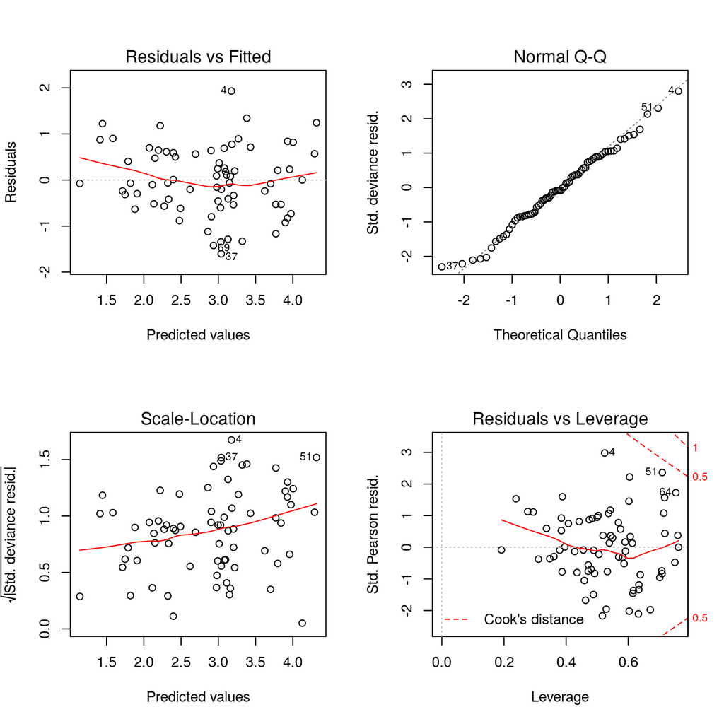

```r
op <- par(mfrow=c(2,2))
plot(llmod)
par(op)
```

And a mosaic plot of predicted probability may be generated:

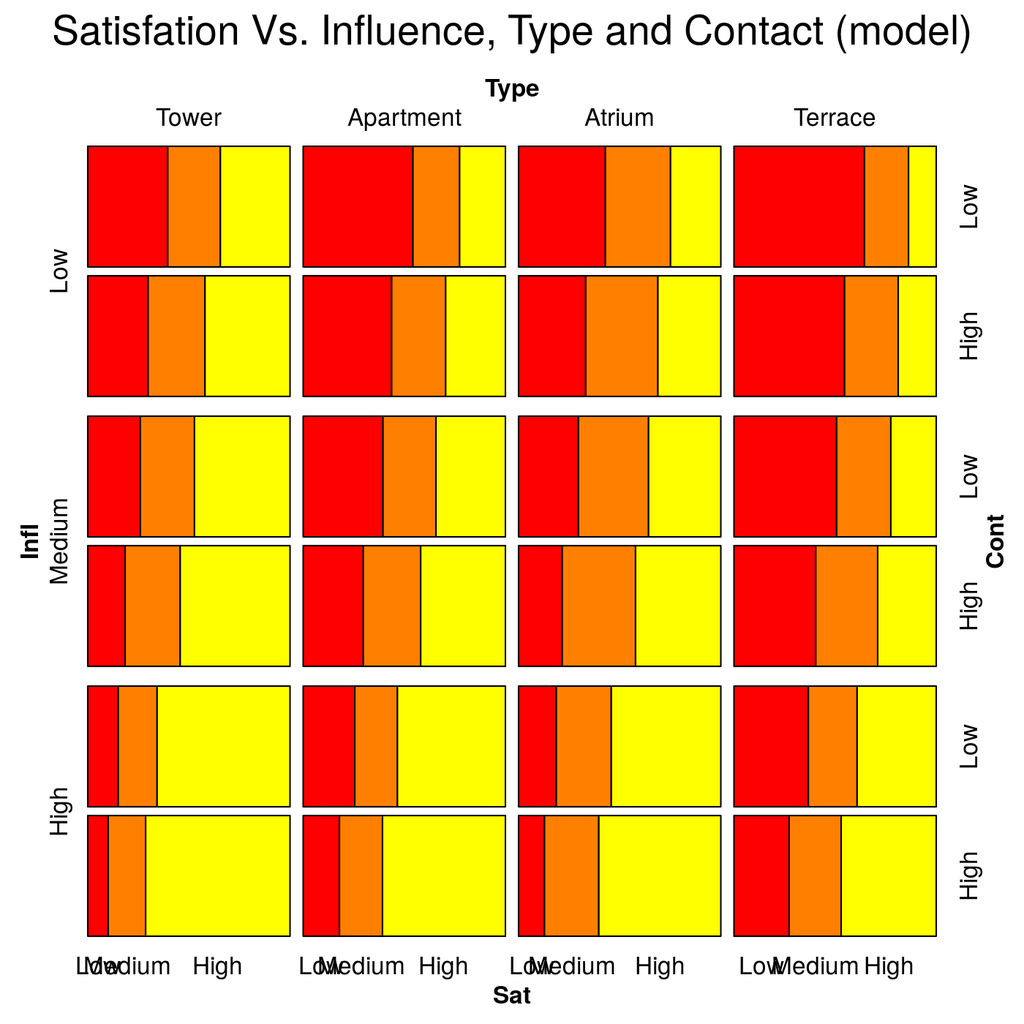

```r
hnames <- lapply(housing[, -5], levels) # omit Freq
house_pm <- predict(llmod, expand.grid(hnames), type = "response") # poisson means
house_pm <- matrix(house_pm, ncol = 3, byrow = T, dimnames = list(NULL, hnames[[1]]))
house_pr <- house_pm/drop(house_pm %*% rep(1, 3))
tb <- expand.grid(hnames[-1])
tb$Sat <- house_pr

tb <- xtabs(Sat~Infl+Type+Cont,data=tb)
names(attr(tb,"dimnames"))[4]="Sat"
mosaic(structable(ftable(tb)),shade=TRUE,
       main = "Satisfation Vs. Influence, Type and Contact (model)",
       highlighting = "Sat",highlighting_fill = heat.colors(3))
```

This is similar to previous mosaic plot of observed proportions.